# Analiza zbioru Iris

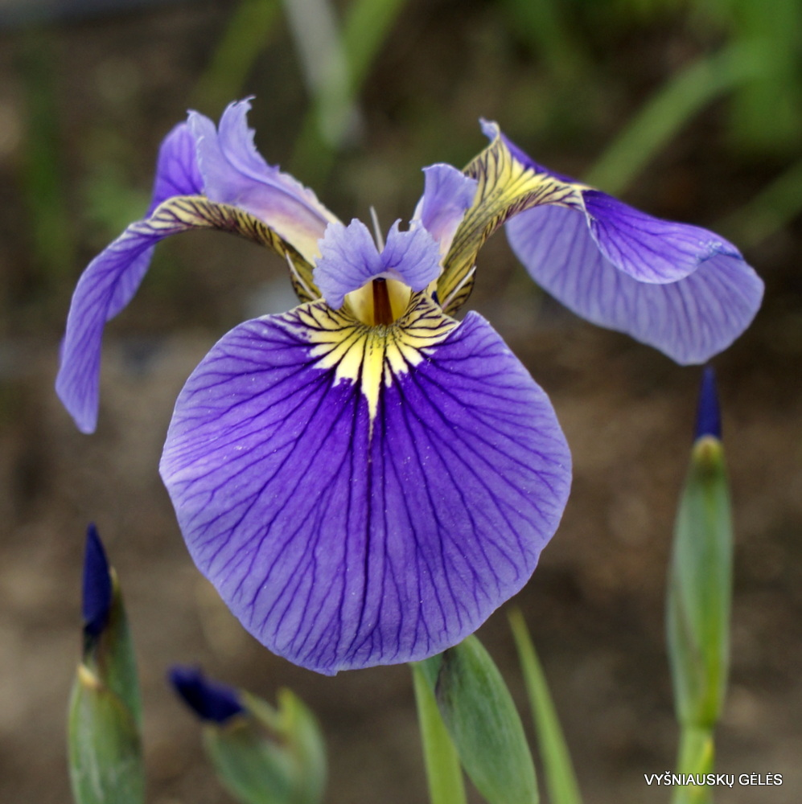

## Cel analizy

#### Czy na podstawie pomiarów poszczególnych części kwiatu można znaleźć różnice pomiędzy trzema gatunkami irysów?

## Krok 1: Ogólny przegląd danych

Dane zawierają 150 wierszy oraz 5 kolumn.

Dane dotyczą 3 gatunków irysów, konkretnie Iris-setosa, Iris-versicolor, Iris-virginica.

W naszych danych każdy z gatunków można rozróżnić również według 4 unikatowych cech, czyli: dlugosc_kielicha, szerokosc_kielicha, dlugosc_platka, szerokosc_platka.

#### Dane są wręcz idealnie zbalansowane, każdy z gatunków posiada po 50 rekordów.

| klasa | dlugosc_kielicha | szerokosc_kielicha | dlugosc_platka | szerokosc_platka |
| --- | --- | --- | --- | --- |
| Iris-setosa | 50 | 50 | 50 | 50 |
| Iris-versicolor | 50 | 50 | 50 | 50 |
| Iris-virginica | 50 | 50 | 50 | 50 |

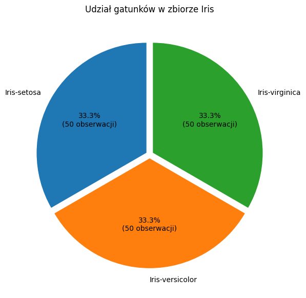

### Spostrzeżenia:

- Mamy łącznie 150 rekordów.
- Są one podzielone na 3 gatunki irysów: 'Iris-setosa', 'Iris-versicolor', 'Iris-virginica'.
- Wszystkie 3 zawierają równo po 50 obserwacji.
- Każdy z gatunków rozróżniamy również poprzez podane wartości opisujące długość i szerokość kielicha, jak i jego płatków.

## Krok 2: Brakujące dane

W danych dotyczących Irysów całkowita liczba brakujących danych wynosi 0.

## Krok 3: Analiza pojedynczych kolumn

| klasa | dlugosc_kielicha | szerokosc_kielicha |
| --- | --- | --- |
| Iris-setosa | 5.800000 | 4.400000 |
| Iris-versicolor | 7.000000 | 3.400000 |
| Iris-virginica | 7.900000 | 3.800000 |

| klasa | dlugosc_platka | szerokosc_platka |
| --- | --- | --- |
| Iris-setosa | 1.900000 | 0.600000 |
| Iris-versicolor | 5.100000 | 1.800000 |
| Iris-virginica | 6.900000 | 2.500000 |

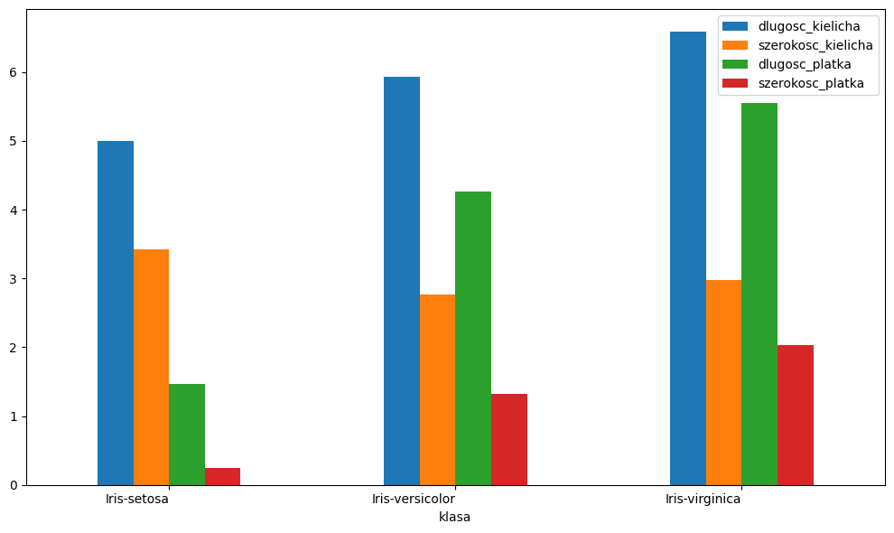

### Spostrzeżenia:

#### Na pierwszy rzut oka da się dostrzec, że pod względem wielkości płatków dominuje odmiana Iris virginica, na drugim miejscu znajduje się Iris versicolor, a ostatni Iris setosa. Jeśli chodzi o rozmiary kielicha, z długością jest analogicznie jak w przypadku płatków, natomiast pod względem szerokości różnice nie są duże, z drobną przewagą na korzyść odmiany Iris setosa.

## Krok 4: Porównanie cech

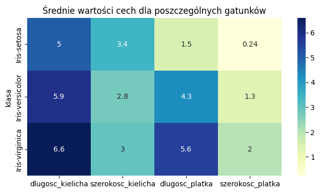

#### Im ciemniejszy kolor, tym większa średnia wartość danej cechy.

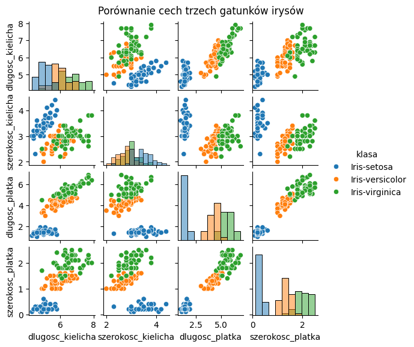

#### Na wykresie widać, że obserwacje Iris versicolor i Iris virginica częściowo się nakładają, natomiast Iris setosa tworzy wyraźnie odrębną grupę.

### Spostrzeżenia:

### 1. Iris setosa

Najsilniesze korelacje:

- Długość_kielicha, szerokość kielicha - całkiem silna dodatnia korelacja ~0.747
- Długość płatka, szerokość płatka - dość słaba dodatnia korelacja ~0.306

### 3. Iris virginica

#### We wszystkich gatunkach dodatnia korelacja długości i szerokości płatków sugeruje, że większe płatki są zazwyczaj również szersze.

## Krok 5: Wartości odstające

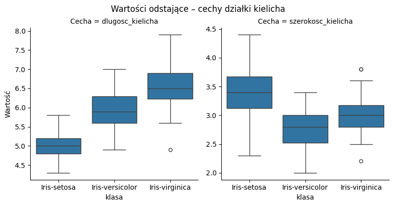

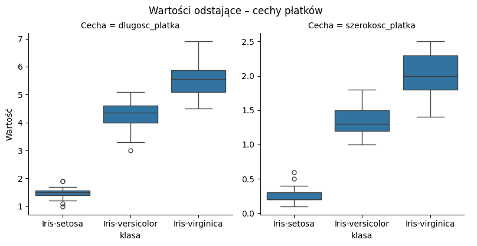

### Spostrzeżenia:

W większości cech nie występują liczne wartości odstające. Pojedyncze obserwacje znajdujące się poza zakresem wąsów nie stanowią istotnego problemu i mogą wynikać z naturalnej zmienności biologicznej badanych roślin.

## Najważniejsze wnioski

- zbiór zawiera 150 obserwacji,
- dane są idealnie zbalansowane (50 obserwacji na gatunek),
- nie występują brakujące dane,
- największe różnice między gatunkami dotyczą płatków,
- Iris setosa jest wyraźnie oddzielona od pozostałych,
- największe wartości cech osiąga Iris virginica.

### Iris setosa:

Zauważalnie najmniejszy z gatunków, chociaż posiada najszerszy kielich wśród całej grupy Irysów z tej analizy. Jego rozmiary to:

- Rozmiar kielicha: długość ~5.0cm, szerokość ~3.4cm
- Rozmiar płatków: długość ~1.46cm, szerokość ~0.24cm

### Iris versicolor:

Pod względem wielkości większości cech zajmuje pozycję pośrednią pomiędzy Iris setosa a Iris virginica. Jego rozmiary to:

- Rozmiar kielicha: długość ~5.93cm, szerokość ~2.77cm
- Rozmiar płatków: długość ~4.26cm, szerokość ~1.32cm

### Iris virginica:

Zdecydowanie największy pomiędzy wszystkimi trzema gatunkami, w szczególności dominuje pod względem wielkości płatków - ich rozmiary wyraźnie przewyższają jego konkurentów. Poszczególne rozmiary to:

- Rozmiar kielicha: długość ~6.58cm, szerokość ~2.97cm
- Rozmiar płatków: długość ~5.55cm, szerokość ~2.02cm